# Análisis Exploratorio Univariado - Uber

Delia Del Águila

En este documento analizaremos mil viajes de Uber obtenidos en https://www.kaggle.com/zusmani/uberdrives

## Limpieza

Nuestro dataset inicia con 1,156 observacion y 7 variables. Despues del proceso de limpieza nuestro dataset termina con 1,154 observaciones y 12 variables, al agregar 5 columnas nuevas para facilitar el manejo de las fechas de inicio y fin del viaje.

### Conociendo cada Variable

**Start Date** Fecha en la que inicio el viaje.  
Nuestros registros abarcan desde el 1 de enero de 2016 a las 21:11hrs hasta el 31 de diciembre del mismo año a las 22:08 hrs. En mayo, entre el 16 y el 23 hubo una caída en la frecuencia de los viajes. Lo mismo sucede entre el 5 y el 12 de septiembre. En total se registraron mas viajes en Viernes y en Jueves. **End Date** Fecha en la que el viaje terminó.  
La mayoría de los viajes no duran más de una hora.

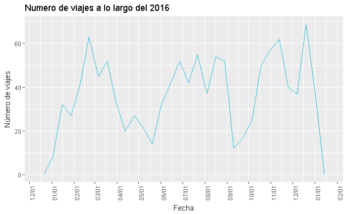

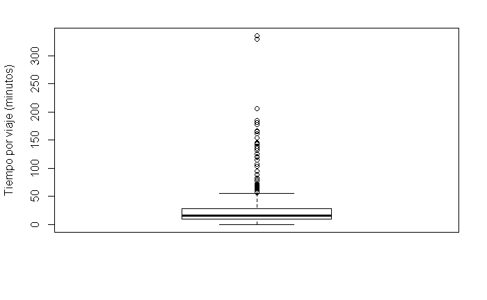

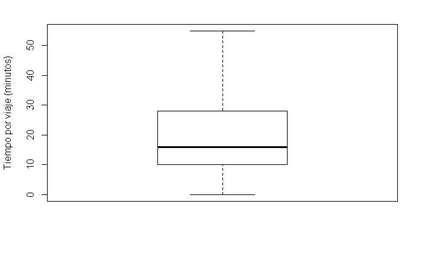

**Category** Tipo de viaje, Personal o de Negocio.  
Los viajes personales solo se registran de Febrero a Abril y durante el mes de Julio.  
Se registran mas viajes de negocio en Viernes.

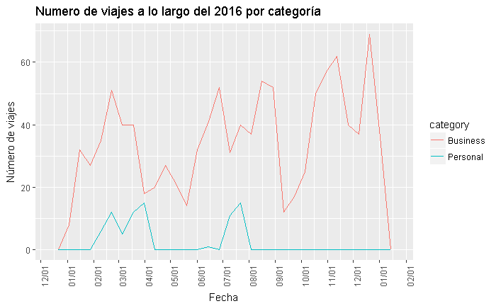

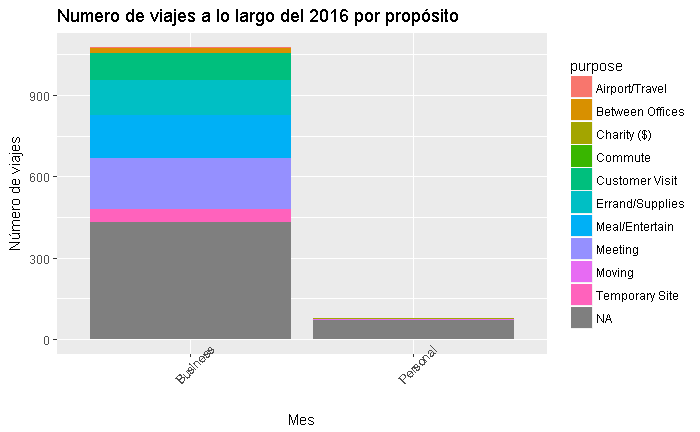

**Start Point and Stop Point**

La mayoría de los viajes se realizaron en Estados Unidos, pero encontramos unos cuantos en la India, Italia y otros países.

```
integer(0)
```

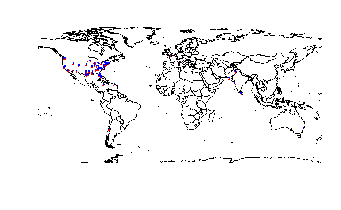

Notemos en el mapa que los puntos rojos representan el inicio de un viaje y los puntos azules representan el destino. Observemos que muchos puntos azules están sobre los rojos. Es decir que hay vaijes tanto de ida, como de regreso.

```
integer(0)
```

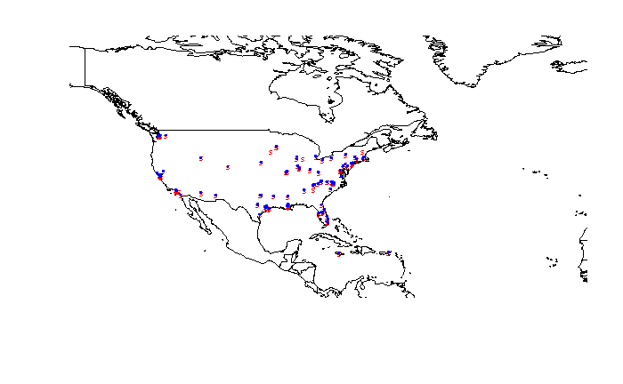

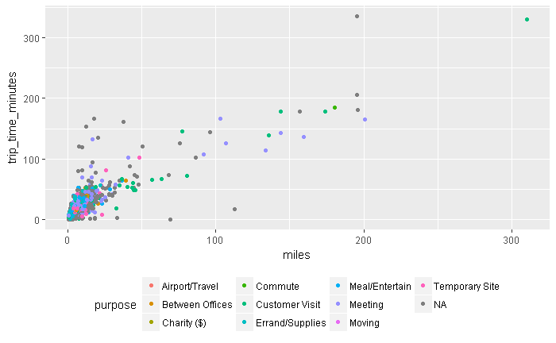